# Bank Portuguese Campaigns

Dimas Aditya

[figure not shown]

# Introduction

The data is related with direct marketing campaigns (phone calls) of a Portuguese banking institution. The classification goal is to predict if the client will subscribe a term deposit (variable y). The data is related with direct marketing campaigns of a Portuguese banking institution. The marketing campaigns were based on phone calls. Often, more than one contact to the same client was required, in order to access if the product (bank term deposit) would be (‘yes’) or not (‘no’) subscribed.

source: https://archive.ics.uci.edu/dataset/222/bank+marketing

#### Business Question

1. How many times on average can a campaign reach success?
2. Recommended best campaign segments?
3. How much savings does someone who is successful in carrying out a campaign have on average?

#### Variable Description

[output not shown]

# 1. Data Preparation

### 1.1 Prerequisites

### 1.2 Importing Data

```r
data <- read.csv("data_input/bank.csv", header = FALSE, sep = ";", quote = "\"")
```

[output not shown]

First things first, let’s read our data.

### 1.3 Data Inspection

```r
summary(data1)
```

```
##      age                job              marital           education
##  Length:4521        Length:4521        Length:4521        Length:4521
##  Class :character   Class :character   Class :character   Class :character
##  Mode  :character   Mode  :character   Mode  :character   Mode  :character
##    default            balance            housing              loan
##  Length:4521        Length:4521        Length:4521        Length:4521
##  Class :character   Class :character   Class :character   Class :character
##  Mode  :character   Mode  :character   Mode  :character   Mode  :character
##    contact              day               month             duration
##  Length:4521        Length:4521        Length:4521        Length:4521
##  Class :character   Class :character   Class :character   Class :character
##  Mode  :character   Mode  :character   Mode  :character   Mode  :character
##    campaign            pdays             previous           poutcome
##  Length:4521        Length:4521        Length:4521        Length:4521
##  Class :character   Class :character   Class :character   Class :character
##  Mode  :character   Mode  :character   Mode  :character   Mode  :character
##       y
##  Length:4521
##  Class :character
##  Mode  :character
```

Based on the table above, let’s select the variables we need.

```r
data2 <- data1 %>% select(
  age, job, marital, education, default, balance, housing, loan, duration, campaign, previous, y)
```

To make it easier to read, we changed some column names.

```r
names(data2)[names(data2) == "y"] <- "result"
names(data2)[names(data2) == "previous"] <- "campaignbef"
names(data2)[names(data2) == "campaign"] <- "campaignnow"
```

Let’s check for missing values in our data.

### 1.4 Missing Value

```r
colSums(is.na(data2))
```

```
##         age         job     marital   education     default     balance
##           0           0           0           0           0           0
##     housing        loan    duration campaignnow campaignbef      result
##           0           0           0           0           0           0
```

To make processing easier, let’s change our data type.

### 1.5 Data Types

```r
data3 <- data2 %>%
  mutate(age = as.numeric(age),
         job = as.factor(job),
         marital = as.factor(marital),
         education = as.factor(education),
         default = as.factor(default),
         balance = as.numeric(balance),
         housing = as.factor(housing),
         loan = as.factor(loan),
         duration = as.numeric(duration),
         campaignnow = as.numeric(campaignnow),
         campaignbef = as.numeric(campaignbef),
         result = as.factor(result)
         )
```

Once we have finished preparing our data, let’s start exploring our data.

# 2. Data Processing

### 2.1 Data Ekploration and Visualization 1

For the first exploration, we will try to answer the business question regarding How many times on average can a campaign achieve success? For this reason, we do aggregation for several variables.

```r
camp <- data3 %>%
 group_by(result) %>%
   summarise(avg_campaign = mean(campaignbef + campaignnow)) %>%
  ungroup() %>%
   mutate(avg_campaign = round(avg_campaign, 1))
camp
```

```
## # A tibble: 2 × 2
##   result avg_campaign
##   <fct>         <dbl>
## 1 no              3.3
## 2 yes             3.4
```

Visualize the data.

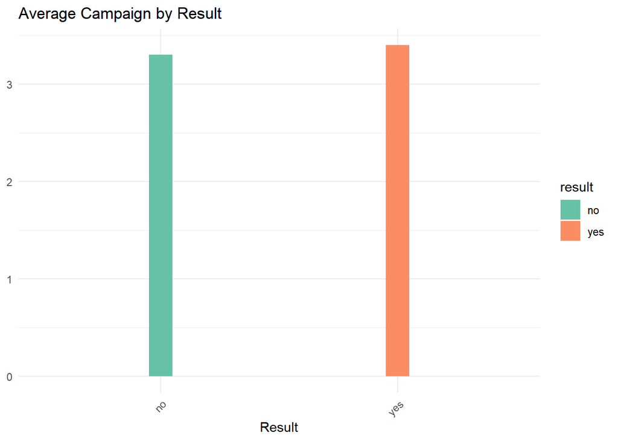

```r
plot1 <- ggplot(camp, aes(x = result, y = avg_campaign, fill = result)) +
  geom_bar(stat = "identity", width = 0.1) + scale_fill_brewer(palette="Set2") +
  labs(x = "Result", y = NULL, title = "Average Campaign by Result") +
  theme_minimal() +
  theme(axis.text.x = element_text(angle = 45, hjust = 1))
plot1
```

Based on the data processing above, from this plot we can see that on average 3.4 new campaigns can produce success until someone wants to carry out the goals of this campaign.

### 2.2 Data Ekploration and Visualization 2

To answer the second question, we try to aggregate based on variables that can group data that describes certain segments.

```r
data3 %>%
  group_by(age, job, marital, education, balance, housing, loan) %>%
  summarise(
    result_yes = sum(result == "yes"),
    result_no = sum(result == "no")
  )
```

[output not shown]

```
## # A tibble: 4,464 × 9
## # Groups:   age, job, marital, education, balance, housing [4,456]
##      age job      marital education balance housing loan  result_yes result_no
##    <dbl> <fct>    <fct>   <fct>       <dbl> <fct>   <fct>      <int>     <int>
##  1    19 student  single  primary       103 no      no             1         0
##  2    19 student  single  secondary     302 no      no             1         0
##  3    19 student  single  unknown         0 no      no             0         1
##  4    19 student  single  unknown      1169 no      no             0         1
##  5    20 student  single  secondary     291 no      no             0         1
##  6    20 student  single  secondary     502 no      no             1         0
##  7    20 student  single  secondary    1191 no      no             0         1
##  8    21 services single  secondary     361 no      no             0         1
##  9    21 services single  secondary    1903 yes     no             0         1
## 10    21 student  single  secondary       6 no      no             0         1
## # ℹ 4,454 more rows
```

Let’s regroup for the job variable.

```r
seg <- data3 %>%
  filter(result == "yes") %>%
group_by(job, result) %>%
  summarise(count = n()) %>%
  arrange(desc(count)) %>%
  ungroup()
```

[output not shown]

```r
seg
```

```
## # A tibble: 12 × 3
##    job           result count
##    <fct>         <fct>  <int>
##  1 management    yes      131
##  2 technician    yes       83
##  3 blue-collar   yes       69
##  4 admin.        yes       58
##  5 retired       yes       54
##  6 services      yes       38
##  7 self-employed yes       20
##  8 student       yes       19
##  9 entrepreneur  yes       15
## 10 housemaid     yes       14
## 11 unemployed    yes       13
## 12 unknown       yes        7
```

Visualize for variable job based data.

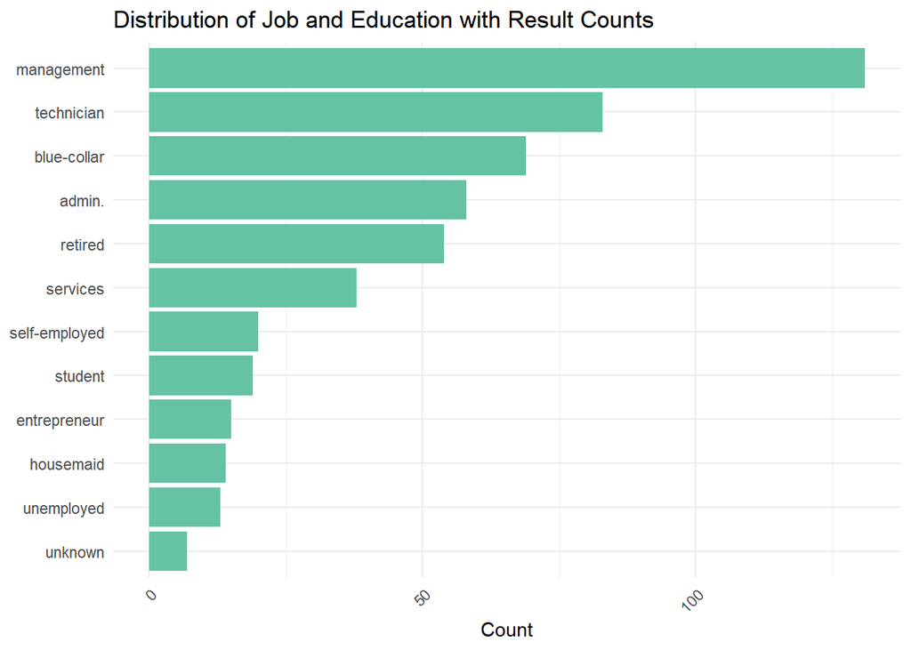

```r
plot2 <- ggplot(data = seg, aes(x = reorder(job, count), y = count, fill = result)) +
  geom_bar(stat = "identity", position = position_dodge()) +
  scale_fill_brewer(palette="Set2") +
  labs(title = "Distribution of Job and Education with Result Counts",
       x = NULL,
       y = "Count") +
  theme_minimal() +
  theme(axis.text.x = element_text(angle = 45, hjust = 1),
        legend.position = "none") +
  coord_flip()
plot2
```

We see that the job segment provides a level of success in the campaign, especially management or managerial jobs.

### 2.3 Data Ekploration and Visualization 3

This time we aggregate based on savings.

```r
bal <- data3 %>%
  group_by(result) %>%
  summarise(median_balance = median(balance, na.rm = TRUE)) %>%
  ungroup()
bal
```

```
## # A tibble: 2 × 2
##   result median_balance
##   <fct>           <dbl>
## 1 no               420.
## 2 yes              710
```

Here’s the visualization.

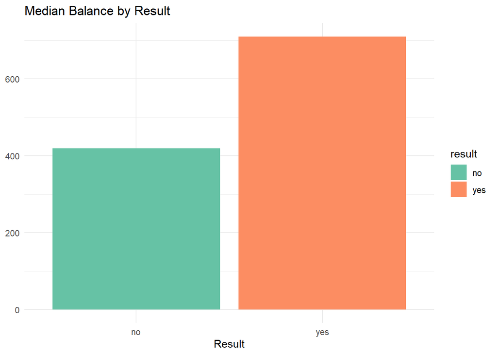

```r
plot3 <- ggplot(bal, aes(x = result, y = median_balance, fill = result)) +
  geom_bar(stat = "identity") +scale_fill_brewer(palette="Set2") +
  labs(title = "Median Balance by Result",
       x = "Result",
       y = NULL) +
  theme_minimal()
plot3
```

Based on the median savings that have the potential for success in this campaign, it is worth 12,518,522 Rupiah or 710 Euros.